# COMPSCIX 415.2 Homework 5/Midterm

Shannon Hamilton

3/1/2018

```r
library(tidyverse)
```

*Github Repository:https://github.com/shannonleehamilton/compscix-415-2-assignments.git*

## The tidyverse packages

*1. Can you name which package is associated with each task below?*

- Plotting - ggplot2
- Data munging/wrangling - dplyr
- Reshaping (speading and gathering) data - tidyr
- Importing/exporting data - readr

*2. Now can you name two functions that you’ve used from each package that you listed above for these tasks?*

- Plotting - ggplot2: geom_point, geom_boxplot
- Data munging/wrangling - dplyr: filter, select
- Reshaping (speading and gathering) data - tidyr:gather, spread
- Importing/exporting data - readr:read_delim, write_delim

## R Basics

*1. Fix this code with the fewest number of changes possible so it works:*

```r
(My_data.name___is.too00ooLong <- c( 1 , 2 , 3 ))
```

```
## [1] 1 2 3
```

*2. Fix this code so it work:*

```r
(my_string <- c('has', 'an', 'error', 'in', 'it'))
```

```
## [1] "has"   "an"    "error" "in"    "it"
```

*3.Look at the code below and comment on what happened to the values in the vector:*

```r
my_vector <- c(1, 2, '3', '4', 5)
my_vector
```

```
## [1] "1" "2" "3" "4" "5"
```

Since some of the values in the vector are indicated to be a string (by putting them in quotations), R converts all of the values in the vector strings instead of recognizing them as numbers.

## Data import/export

*1. Download the rail_trail.txt file from Canvas (in the Midterm Exam section here) and successfully import it into R. Prove that it was imported successfully by including your import code and taking a glimpse of the result*

```r
file_path <- '/Users/shamilto/Downloads/rail_trail.txt'
rail <-read_delim(file_path,delim="|")
glimpse(rail)
```

```
## Observations: 90
## Variables: 10
## $ hightemp   <int> 83, 73, 74, 95, 44, 69, 66, 66, 80, 79, 78, 65, 41,...
## $ lowtemp    <int> 50, 49, 52, 61, 52, 54, 39, 38, 55, 45, 55, 48, 49,...
## $ avgtemp    <dbl> 66.5, 61.0, 63.0, 78.0, 48.0, 61.5, 52.5, 52.0, 67....
## $ spring     <int> 0, 0, 1, 0, 1, 1, 1, 1, 0, 0, 0, 1, 1, 0, 0, 1, 0, ...
## $ summer     <int> 1, 1, 0, 1, 0, 0, 0, 0, 1, 1, 1, 0, 0, 0, 0, 0, 1, ...
## $ fall       <int> 0, 0, 0, 0, 0, 0, 0, 0, 0, 0, 0, 0, 0, 1, 1, 0, 0, ...
## $ cloudcover <dbl> 7.6, 6.3, 7.5, 2.6, 10.0, 6.6, 2.4, 0.0, 3.8, 4.1, ...
## $ precip     <dbl> 0.00, 0.29, 0.32, 0.00, 0.14, 0.02, 0.00, 0.00, 0.0...
## $ volume     <int> 501, 419, 397, 385, 200, 375, 417, 629, 533, 547, 4...
## $ weekday    <int> 1, 1, 1, 0, 1, 1, 1, 0, 0, 1, 1, 1, 1, 1, 1, 1, 0, ...
```

*2. Export the file into an R-specific format and name it “rail_trail.rds”. Make sure you define the path correctly so that you know where it gets saved. Then reload the file. Include your export and import code and take another glimpse.*

```r
saveRDS(rail, file = "/Users/shamilto/Downloads/rail_trail.rds")
```

```r
file_path2 <- '/Users/shamilto/Downloads/rail_trail.rds'
rail2 <-read_rds(file_path2)
glimpse(rail2)
```

```
## Observations: 90
## Variables: 10
## $ hightemp   <int> 83, 73, 74, 95, 44, 69, 66, 66, 80, 79, 78, 65, 41,...
## $ lowtemp    <int> 50, 49, 52, 61, 52, 54, 39, 38, 55, 45, 55, 48, 49,...
## $ avgtemp    <dbl> 66.5, 61.0, 63.0, 78.0, 48.0, 61.5, 52.5, 52.0, 67....
## $ spring     <int> 0, 0, 1, 0, 1, 1, 1, 1, 0, 0, 0, 1, 1, 0, 0, 1, 0, ...
## $ summer     <int> 1, 1, 0, 1, 0, 0, 0, 0, 1, 1, 1, 0, 0, 0, 0, 0, 1, ...
## $ fall       <int> 0, 0, 0, 0, 0, 0, 0, 0, 0, 0, 0, 0, 0, 1, 1, 0, 0, ...
## $ cloudcover <dbl> 7.6, 6.3, 7.5, 2.6, 10.0, 6.6, 2.4, 0.0, 3.8, 4.1, ...
## $ precip     <dbl> 0.00, 0.29, 0.32, 0.00, 0.14, 0.02, 0.00, 0.00, 0.0...
## $ volume     <int> 501, 419, 397, 385, 200, 375, 417, 629, 533, 547, 4...
## $ weekday    <int> 1, 1, 1, 0, 1, 1, 1, 0, 0, 1, 1, 1, 1, 1, 1, 1, 0, ...
```

## Visualization

*2. Reproduce this graphic using the diamonds data set.*

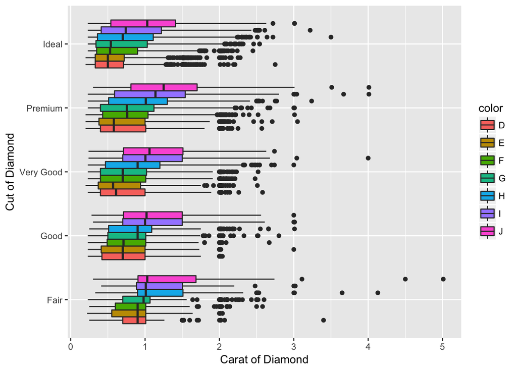

```r
 data("diamonds")

ggplot(diamonds) +
  geom_boxplot(mapping = aes(x = cut, y = carat, fill=color)) +
  xlab("Cut of Diamond") +
  ylab("Carat of Diamond") +
  coord_flip()
```

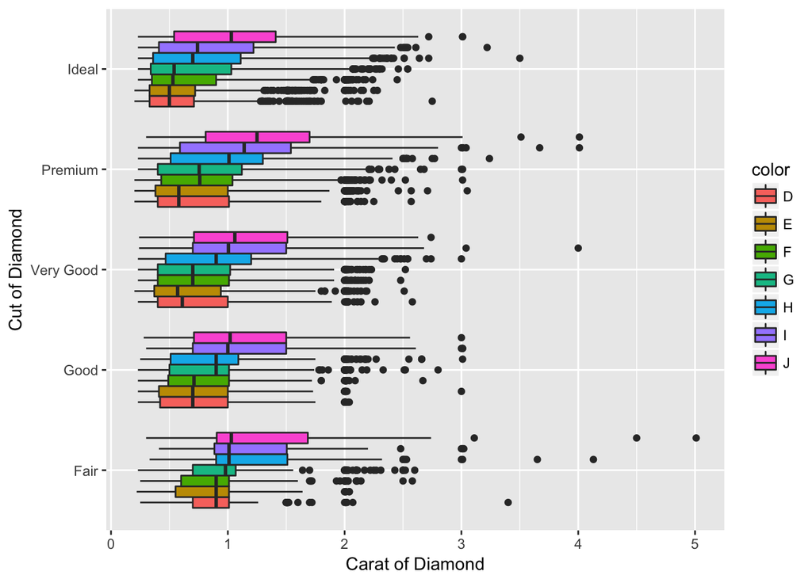

```r
 data("diamonds")

ggplot(diamonds) +
  geom_boxplot(mapping = aes(x = cut, y = carat, fill=color)) +
  xlab("Cut of Diamond") +
  ylab("Carat of Diamond") +
  coord_flip()
```